# Reproducible Research: Activity Monitoring

2026-02-27

## Introduction

This assignment makes use of data from a personal activity monitoring device. This device collects data at 5 minute intervals throughout the day. The data consists of two months of data from an anonymous individual collected during the months of October and November, 2012.

## 1. Loading and preprocessing the data

We load the dataset from the CSV file and convert the date column into a proper Date class for analysis.

```r
activity <- read.csv("activity.csv")
activity$date <- as.Date(activity$date, format = "%Y-%m-%d")
str(activity)
```

```
## 'data.frame':    17568 obs. of  3 variables:
##  $ steps   : int  NA NA NA NA NA NA NA NA NA NA ...
##  $ date    : Date, format: "2012-10-01" "2012-10-01" ...
##  $ interval: int  0 5 10 15 20 25 30 35 40 45 ...
```

## 2. Mean Total Number of Steps Taken Per Day

We calculate the total number of steps taken each day, ignoring missing values. Then we create a histogram and compute the mean and median.

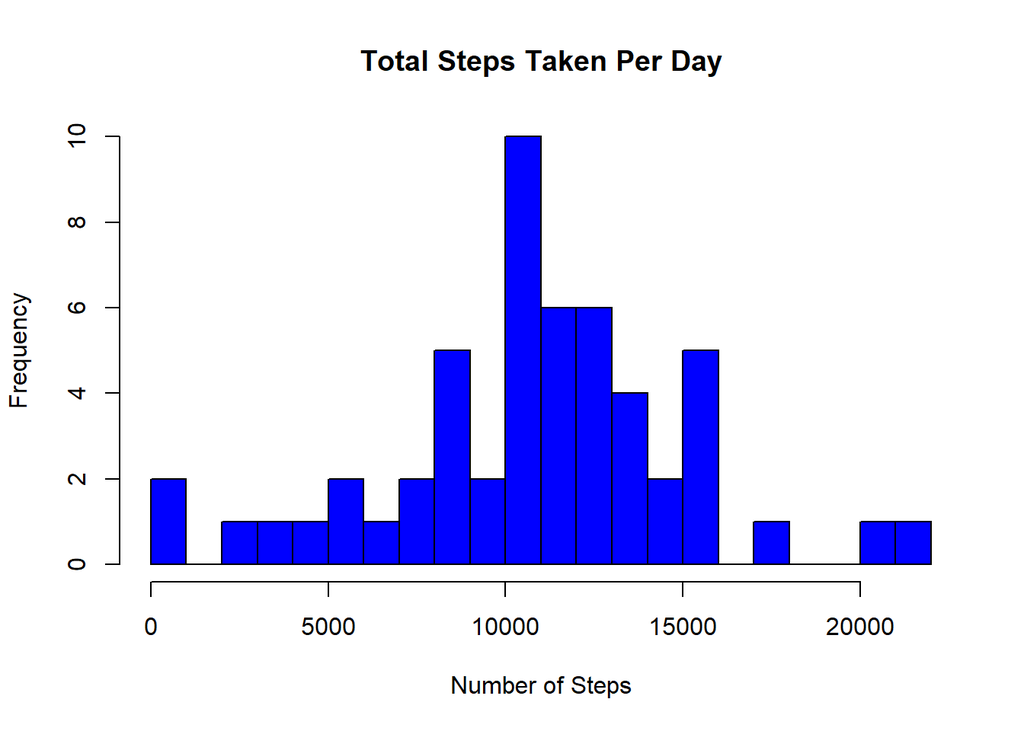

```r
daily_steps <- aggregate(steps ~ date, data = activity, sum, na.rm = TRUE)

hist(daily_steps$steps,
     breaks = 20,
     col = "blue",
     main = "Total Steps Taken Per Day",
     xlab = "Number of Steps")
```

```r
mean_val <- mean(daily_steps$steps)
median_val <- median(daily_steps$steps)
```

Mean total number of steps per day: 10766.19  
Median total number of steps per day: 10765

## 3. Average Daily Activity Pattern

We calculate the average number of steps taken for each 5 minute interval across all days.

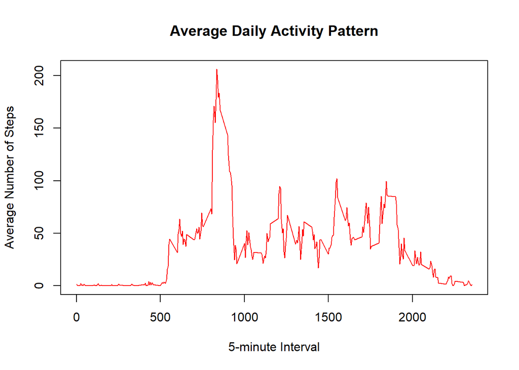

```r
interval_avg <- aggregate(steps ~ interval,data = activity,mean,na.rm = TRUE)

plot(interval_avg$interval,interval_avg$steps,type = "l",col = "red",main ="Average Daily Activity Pattern",xlab = "5-minute Interval",ylab = "Average Number of Steps")
```

```r
max_interval <- interval_avg$interval[which.max(interval_avg$steps)]
```

The 5-minute interval with the maximum average number of steps is:  
835

## 4. Imputing Missing Values

First, we calculate the total number of missing values. Then we replace all missing values using the mean for that specific 5-minute interval.

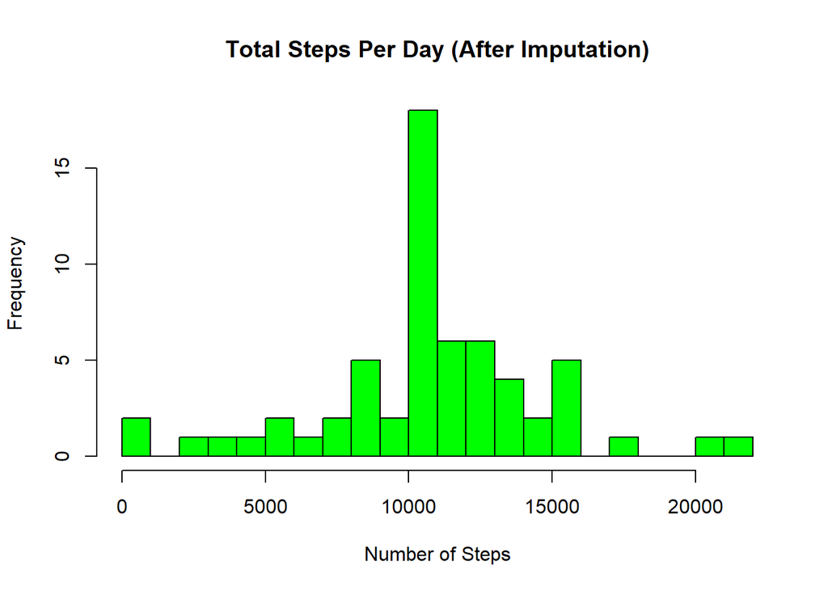

```r
missing_count <- sum(is.na(activity$steps))

imputed_data <- activity

for (i in 1:nrow(imputed_data)) {
  if (is.na(imputed_data$steps[i])) {
    interval_value <- imputed_data$interval[i]
    imputed_data$steps[i] <- interval_avg$steps[
      interval_avg$interval == interval_value
    ]
  }
}

daily_steps_imputed <- aggregate(steps ~ date,
                                 data = imputed_data,
                                 sum)

hist(daily_steps_imputed$steps,
     breaks = 20,
     col = "green",
     main = "Total Steps Per Day (After Imputation)",
     xlab = "Number of Steps")
```

```r
new_mean <- mean(daily_steps_imputed$steps)
new_median <- median(daily_steps_imputed$steps)
```

Total number of missing values: 2304  
Mean after imputation: 10766.19  
Median after imputation: 10766.19

## 5. Are there Differences in Activity Patterns Between Weekdays and Weekends?

We classify each date as weekday or weekend and compare the activity patterns.

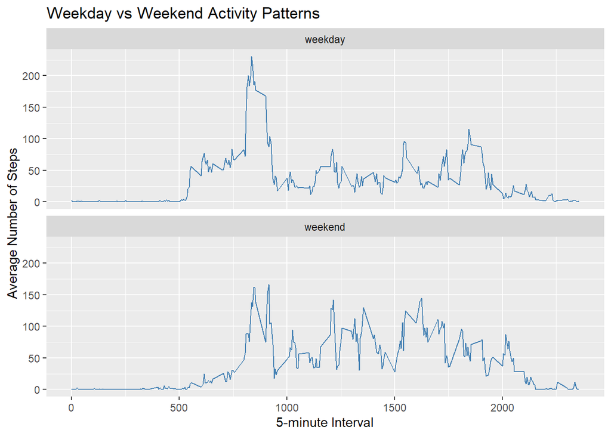

```r
imputed_data$day_type <- ifelse(
  weekdays(imputed_data$date) %in% c("Saturday", "Sunday"),
  "weekend",
  "weekday"
)

imputed_data$day_type <- as.factor(imputed_data$day_type)

library(ggplot2)

final_avg <- aggregate(steps ~ interval + day_type,
                       data = imputed_data,
                       mean)

ggplot(final_avg, aes(x = interval, y = steps)) +
  geom_line(color = "steelblue") +
  facet_wrap(~ day_type, ncol = 1) +
  labs(title = "Weekday vs Weekend Activity Patterns",
       x = "5-minute Interval",
       y = "Average Number of Steps")
```